# Pembukaan

Assalamualaikum warahmatullahi wabarakatuh. Mohon ijin pimpinan. Dengan ini saya sampaikan data mengenai persekolahan di Indonesia, wabil khusus perbandingan antara kondisi nasional dan Papua (Provinsi Papua dan Provinsi Papua Barat). Data diperoleh dari situs Data Pokok Pendidikan Dasar dan Menengah (https://dapo.dikdasmen.kemdikbud.go.id/). Maksud dan tujuan dari ini adalah untuk mengakui adanya privilese saya sebagai kelas menengah ngehe dan belajar apa yang sekiranya terjadi di Papua, setidaknya dari segi pendidikan.

TL;DR: hasilnya fucked up cuy.

Kode, slide presentasi, notebook: https://github.com/ledwindra/pendidikan-papua. Jangan lupa like, fork, kritik, caciannya. 🙏🏽

```python
import matplotlib.pyplot as plt
import pandas as pd
import re
import seaborn as sns
from bs4 import BeautifulSoup
```

```python
df = pd.read_csv('./data/subdistrict.csv', header=None)
df.columns = [
    'nama',
    'sekolah_id',
    'kode_wilayah_induk_kecamatan',
    'induk_provinsi',
    'kode_wilayah_induk_provinsi',
    'bentuk_pendidikan',
    'status_sekolah',
    'sekolah_id_enkrip'
]
df['sekolah_id_enkrip'] = df.apply(lambda x: x['sekolah_id_enkrip'].replace(' ', ''), axis=1)

sch = pd.read_csv('./data/school.csv', header=None)
sch.columns = [
    'rombel',
    'guru_kelas',
    'guru_matematika',
    'guru_bahasa_indonesia',
    'guru_bahasa_inggris',
    'guru_sejarah_indonesia',
    'guru_pkn',
    'guru_penjaskes',
    'guru_agama_budi_pekerti',
    'guru_seni_budaya',
    'ptk_laki',
    'ptk_perempuan',
    'pegawai_laki',
    'pegawai_perempuan',
    'pd_kelas_1_laki',
    'pd_kelas_1_perempuan',
    'pd_kelas_2_laki',
    'pd_kelas_2_perempuan',
    'pd_kelas_3_laki',
    'pd_kelas_3_perempuan',
    'pd_kelas_4_laki',
    'pd_kelas_4_perempuan',
    'pd_kelas_5_laki',
    'pd_kelas_5_perempuan',
    'pd_kelas_6_laki',
    'pd_kelas_6_perempuan',
    'pd_kelas_7_laki',
    'pd_kelas_7_perempuan',
    'pd_kelas_8_laki',
    'pd_kelas_8_perempuan',
    'pd_kelas_9_laki',
    'pd_kelas_9_perempuan',
    'pd_kelas_10_laki',
    'pd_kelas_10_perempuan',
    'pd_kelas_11_laki',
    'pd_kelas_11_perempuan',
    'pd_kelas_12_laki',
    'pd_kelas_12_perempuan',
    'pd_kelas_13_laki',
    'pd_kelas_13_perempuan',
    'jumlah_kirim',
    'ptk',
    'pegawai',
    'pd',
    'pd_laki',
    'pd_perempuan',
    'jml_rk',
    'jml_lab',
    'jml_perpus',
    'identitas_valid',
    'ptk_valid',
    'pd_valid',
    'prasarana_valid',
    'total_valid',
    'kecukupan_air',
    'memproses_air',
    'minum_siswa',
    'siswa_bawa_air',
    'toilet_siswa_kk',
    'sumber_air_str',
    'ketersediaan_air',
    'tipe_jamban',
    'jml_wastafel',
    'a_sabun_air_mengalir',
    'jml_jamban_digunakan',
    'jml_jamban_tidak_digunakan',
    'sekolah_id_enkrip'
]
```

```python
df = pd.merge(df, sch, how='inner', on='sekolah_id_enkrip')
```

```python
df.columns
```

```
Index(['nama', 'sekolah_id', 'kode_wilayah_induk_kecamatan', 'induk_provinsi',
       'kode_wilayah_induk_provinsi', 'bentuk_pendidikan', 'status_sekolah',
       'sekolah_id_enkrip', 'rombel', 'guru_kelas', 'guru_matematika',
       'guru_bahasa_indonesia', 'guru_bahasa_inggris',
       'guru_sejarah_indonesia', 'guru_pkn', 'guru_penjaskes',
       'guru_agama_budi_pekerti', 'guru_seni_budaya', 'ptk_laki',
       'ptk_perempuan', 'pegawai_laki', 'pegawai_perempuan', 'pd_kelas_1_laki',
       'pd_kelas_1_perempuan', 'pd_kelas_2_laki', 'pd_kelas_2_perempuan',
       'pd_kelas_3_laki', 'pd_kelas_3_perempuan', 'pd_kelas_4_laki',
       'pd_kelas_4_perempuan', 'pd_kelas_5_laki', 'pd_kelas_5_perempuan',
       'pd_kelas_6_laki', 'pd_kelas_6_perempuan', 'pd_kelas_7_laki',
       'pd_kelas_7_perempuan', 'pd_kelas_8_laki', 'pd_kelas_8_perempuan',
       'pd_kelas_9_laki', 'pd_kelas_9_perempuan', 'pd_kelas_10_laki',
       'pd_kelas_10_perempuan', 'pd_kelas_11_laki', 'pd_kelas_11_perempuan',
       'pd_kelas_12_laki', 'pd_kelas_12_perempuan', 'pd_kelas_13_laki',
       'pd_kelas_13_perempuan', 'jumlah_kirim', 'ptk', 'pegawai', 'pd',
       'pd_laki', 'pd_perempuan', 'jml_rk', 'jml_lab', 'jml_perpus',
       'identitas_valid', 'ptk_valid', 'pd_valid', 'prasarana_valid',
       'total_valid', 'kecukupan_air', 'memproses_air', 'minum_siswa',
       'siswa_bawa_air', 'toilet_siswa_kk', 'sumber_air_str',
       'ketersediaan_air', 'tipe_jamban', 'jml_wastafel',
       'a_sabun_air_mengalir', 'jml_jamban_digunakan',
       'jml_jamban_tidak_digunakan'],
      dtype='object')
```

```python
get_mean = lambda x: df.groupby('is_papua')[x].agg('mean').reset_index()
```

```python
def get_mean_categorical(metrics):
    national = {
        'is_papua': False,
        f'{metrics}_pct': len(df[(df['is_papua'] == False) & (df[metrics] == True)]) / len(df[df['is_papua'] == False])
    }
    papua = {
        'is_papua': True,
        f'{metrics}_pct': len(df[(df['is_papua'] == True) & (df[metrics] == True)]) / len(df[df['is_papua'] == True])
    }

    return pd.DataFrame([national, papua])
```

```python
def get_bar(metrics, ycol, title):

    ax = sns.catplot(
        x=['Nasional', 'Papua'],
        y=ycol,
        data=metrics,
        kind='bar'
    )
    ax.set(
        xlabel='',
        ylabel='',
        title=title
    )
```

```python
def get_bar_multiple(metrics, title):
    data = list(set((df[metrics])))
    data = [str(x) for x in data]
    data = sorted(data)
    data = dict(zip(data, data))
    data = dict((re.sub(' |\/', '_', key).lower(), value) for (key, value) in data.items())
    for key, value in data.items():
        if key != 'nan':
            df[key] = df.apply(lambda x: x[metrics] == value, axis=1)
            data = df.groupby(['is_papua', key])['sekolah_id_enkrip'].agg('count').to_frame().reset_index()
            get_bar(get_mean_categorical(key), f'{key}_pct', f'{title}: {value}')
```

## Perbandingan jumlah rata-rata nasional dan Papua

Perlu dicatat bahwa dalam konteks ini Provinsi Papua dan Papua Barat dijadikan satu.

```python
df['is_papua'] = df.apply(lambda x: (x['induk_provinsi'] == 'Prov. Papua') | (x['induk_provinsi'] == 'Prov. Papua Barat'), axis=1)
```

### Guru kelas

```python
# meaningless data from source
get_mean('guru_kelas')
```

|  | is_papua | guru_kelas |
| --- | --- | --- |
| 0 | False | 0.0 |
| 1 | True | 0.0 |

### Guru matematika

```python
# meaningless data from source
get_mean('guru_matematika')
```

|  | is_papua | guru_matematika |
| --- | --- | --- |
| 0 | False | 0.0 |
| 1 | True | 0.0 |

### Guru bahasa Indonesia

```python
# meaningless data from source
get_mean('guru_bahasa_indonesia')
```

|  | is_papua | guru_bahasa_indonesia |
| --- | --- | --- |
| 0 | False | 0.0 |
| 1 | True | 0.0 |

### Guru bahasa Inggris

```python
# meaningless data from source
get_mean('guru_bahasa_inggris')
```

|  | is_papua | guru_bahasa_inggris |
| --- | --- | --- |
| 0 | False | 0.0 |
| 1 | True | 0.0 |

### Guru sejarah Indonesia

```python
# meaningless data from soure
get_mean('guru_sejarah_indonesia')
```

|  | is_papua | guru_sejarah_indonesia |
| --- | --- | --- |
| 0 | False | 0.0 |
| 1 | True | 0.0 |

### Guru PKN

```python
# meaningless data from source
get_mean('guru_pkn')
```

|  | is_papua | guru_pkn |
| --- | --- | --- |
| 0 | False | 0.0 |
| 1 | True | 0.0 |

### Guru penjaskes

```python
# meaningless data from source
get_mean('guru_penjaskes')
```

|  | is_papua | guru_penjaskes |
| --- | --- | --- |
| 0 | False | 0.0 |
| 1 | True | 0.0 |

### Guru agama budi pekerti

```python
# meaningless data from source
get_mean('guru_agama_budi_pekerti')
```

|  | is_papua | guru_agama_budi_pekerti |
| --- | --- | --- |
| 0 | False | 0.0 |
| 1 | True | 0.0 |

### Guru seni budaya

```python
# meaningless data from source
get_mean('guru_seni_budaya')
```

|  | is_papua | guru_seni_budaya |
| --- | --- | --- |
| 0 | False | 0.0 |
| 1 | True | 0.0 |

### Pendidik dan tenaga kependidikan (PTK)

```python
get_mean('ptk')
```

|  | is_papua | ptk |
| --- | --- | --- |
| 0 | False | 12.402281 |
| 1 | True | 8.696262 |

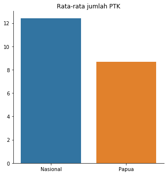

```python
get_bar(get_mean('ptk'), 'ptk', 'Rata-rata jumlah PTK')
```

```python
get_mean('ptk_laki')
```

|  | is_papua | ptk_laki |
| --- | --- | --- |
| 0 | False | 4.305703 |
| 1 | True | 3.560748 |

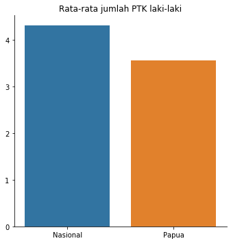

```python
get_bar(get_mean('ptk_laki'), 'ptk_laki', 'Rata-rata jumlah PTK laki-laki')
```

```python
get_mean('ptk_perempuan')
```

|  | is_papua | ptk_perempuan |
| --- | --- | --- |
| 0 | False | 8.096578 |
| 1 | True | 5.135514 |

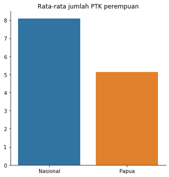

```python
get_bar(get_mean('ptk_perempuan'), 'ptk_perempuan', 'Rata-rata jumlah PTK perempuan')
```

### Pegawai

```python
get_mean('pegawai')
```

|  | is_papua | pegawai |
| --- | --- | --- |
| 0 | False | 3.006717 |
| 1 | True | 1.705607 |

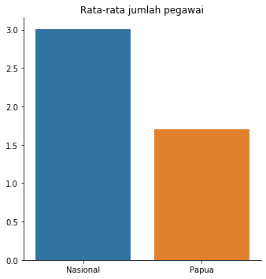

```python
get_bar(get_mean('pegawai'), 'pegawai', 'Rata-rata jumlah pegawai')
```

```python
get_mean('pegawai_laki')
```

|  | is_papua | pegawai_laki |
| --- | --- | --- |
| 0 | False | 1.766793 |
| 1 | True | 1.172897 |

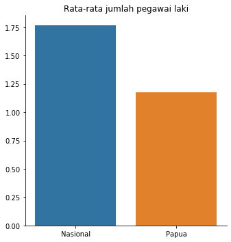

```python
get_bar(get_mean('pegawai_laki'), 'pegawai_laki', 'Rata-rata jumlah pegawai laki')
```

```python
get_mean('pegawai_perempuan')
```

|  | is_papua | pegawai_perempuan |
| --- | --- | --- |
| 0 | False | 1.239924 |
| 1 | True | 0.532710 |

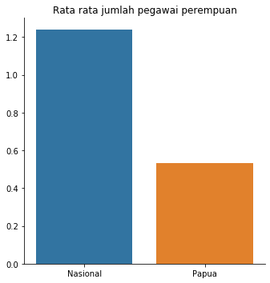

```python
get_bar(get_mean('pegawai_perempuan'), 'pegawai_perempuan', 'Rata rata jumlah pegawai perempuan')
```

### Peserta didik (PD)

```python
get_mean('pd')
```

|  | is_papua | pd |
| --- | --- | --- |
| 0 | False | 204.008776 |
| 1 | True | 181.607656 |

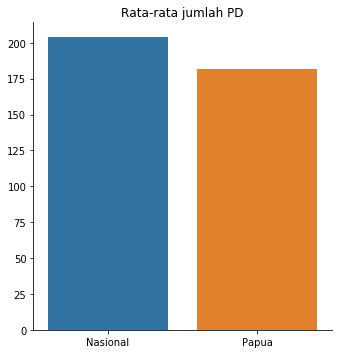

```python
get_bar(get_mean('pd'), 'pd', 'Rata-rata jumlah PD')
```

```python
get_mean('pd_laki')
```

|  | is_papua | pd_laki |
| --- | --- | --- |
| 0 | False | 105.339227 |
| 1 | True | 95.822967 |

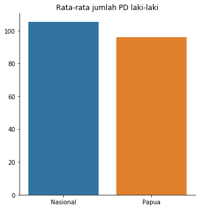

```python
get_bar(get_mean('pd_laki'), 'pd_laki', 'Rata-rata jumlah PD laki-laki')
```

```python
get_mean('pd_perempuan')
```

|  | is_papua | pd_perempuan |
| --- | --- | --- |
| 0 | False | 98.669550 |
| 1 | True | 85.784689 |

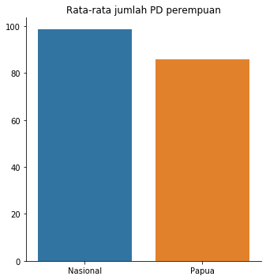

```python
get_bar(get_mean('pd_perempuan'), 'pd_perempuan', 'Rata-rata jumlah PD perempuan')
```

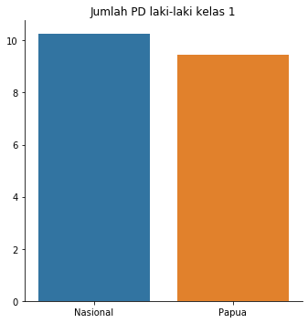

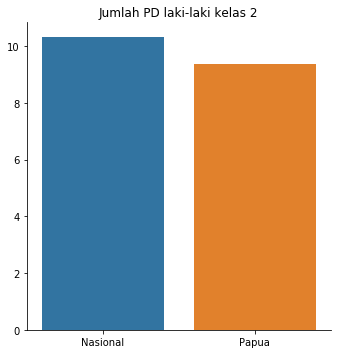

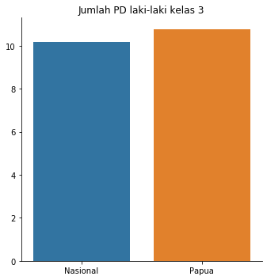

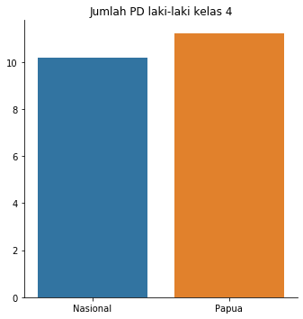

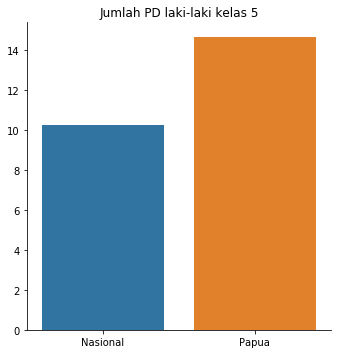

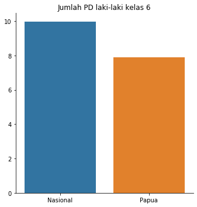

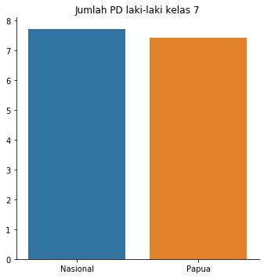

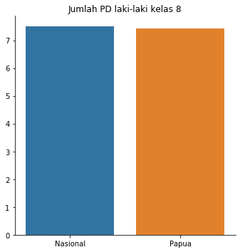

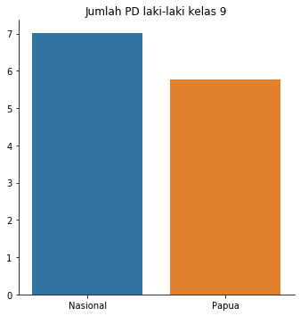

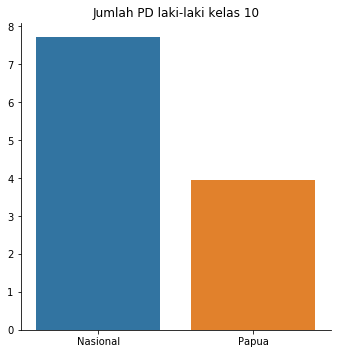

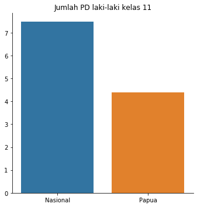

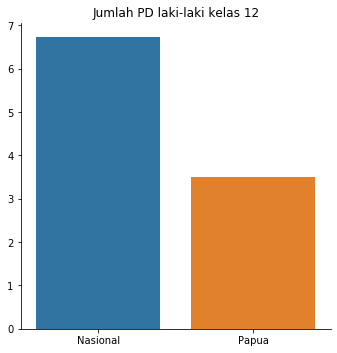

```python
for i in range(1, 13):
    pd_laki = get_mean(f'pd_kelas_{i}_laki')
    get_bar(pd_laki, f'pd_kelas_{i}_laki', f'Jumlah PD laki-laki kelas {i}')
```